# Introduction to Time Series II

Gustavo Magaña López

6/3/2020

In this case we are using the following packages:

```r
library(ggplot2)
library(readr)
library(RcppTOML)
library(lubridate)
library(reshape2)
library(forecast)
library(gridExtra)
```

## Reproducibility

In order for you to reproduce the results found in this notebook, we must set a seed for the random number generator. As mentioned on the previous chapter we parse our config which includes file locations.

```r
  set.seed(204) # so you can reproduce the results
  config <- parseToml("../config.toml") # The only magic constant will be the path to the config file.
```

## Statistical analysis of time series

The collection of observations or realisations that make up a time series: let’s say $n$ random variables observed at arbitrary time points $t_{1}, ..., t_{n}$ can be completely described by the joint distribution function. This function is then evaluated as the probability that the values of the series are jointly less than the $n$ constants $c_{1}, ..., c_{n}$.

$$F_{t_{1}, t_{2}, .., t_{n}} (c_{1}, c_{2}, ... c_{n}) = Pr(x_{t_{1}} \leq c_{1}, x_{t_{2}} \leq c_{2}, ..., x_{t_{n}} \leq c_{n})$$

Nevertheless this function is of little practical value in the analysis we are interested in performing. The marginal distribution and density functions, when they exist, are informative when looking at the marginal behaviour of a series.

$$F_{t}(x) = P\{ x_{t} \leq x\} \;\;\;\;\;\; ;
\;\;\;\;\;\; f_{t}(x) = \frac{\partial F_{t}(x)}{\partial x}$$

The main metrics that we will discuss (and mostly show a practical example), are the following:

- Mean
- Autocovariance
- Autocorrelation
- Cross-covariance
- Cross-correlation

These are fundamental when talking about *stationary* time series. This concept will be defined, perhaps in another chapter, to enhance future understanding of models and their underlying assumptions. **Note** that each one will have its general definition (for the population and the sample).

## Mean function

This is analogue to our traditional expected value operator. Note that when there is no confusion, the subscript $x$ becomes redundant.

$$\mu_{xt} = E(x_{t}) = \int_{-\infty}^{\infty}xf_{t}(x)dx$$

When estimating this population mean, the default statistic is the *sample mean*. In other words we are implying $E(\bar{x}) = \mu$. It is defined as follows:

$$\bar{x} = \frac{1}{n}\sum_{t=1}^{n}x_{t}$$

Taking the cotinuous glucose montiring of a non diabetic patient, we can visualise that the builtin *mean* function can provide the *sample mean* with simplicity.

```r
glc <- read_csv(config$data$build$nondiab1)
#glc$datetime <- sapply(glc$datetime, as_datetime)
mean(glc$glucose)
```

```
## [1] 99.31518
```

We can observe the mean on top of the time series:

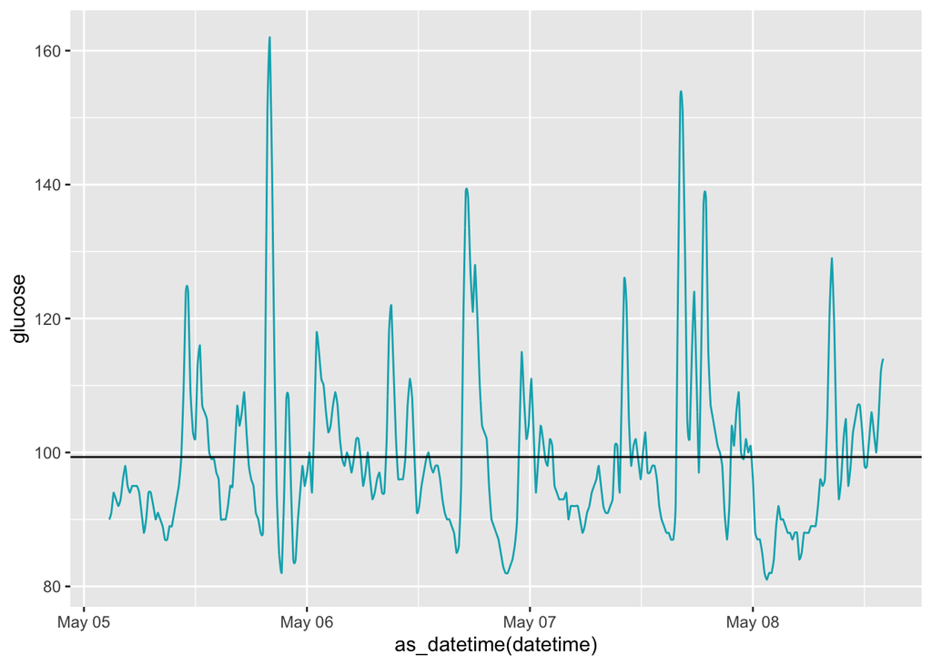

```r
# Display the time series
glc.ts.plt <- ggplot(data = glc, aes(x = as_datetime(datetime), y = glucose)) +
  geom_line(color = "#00AFBB") +
  geom_hline(yintercept =  mean(glc$glucose)) # Add an horizontal line : the mean
print(glc.ts.plt)
```

Or simultaneously with its distplot:

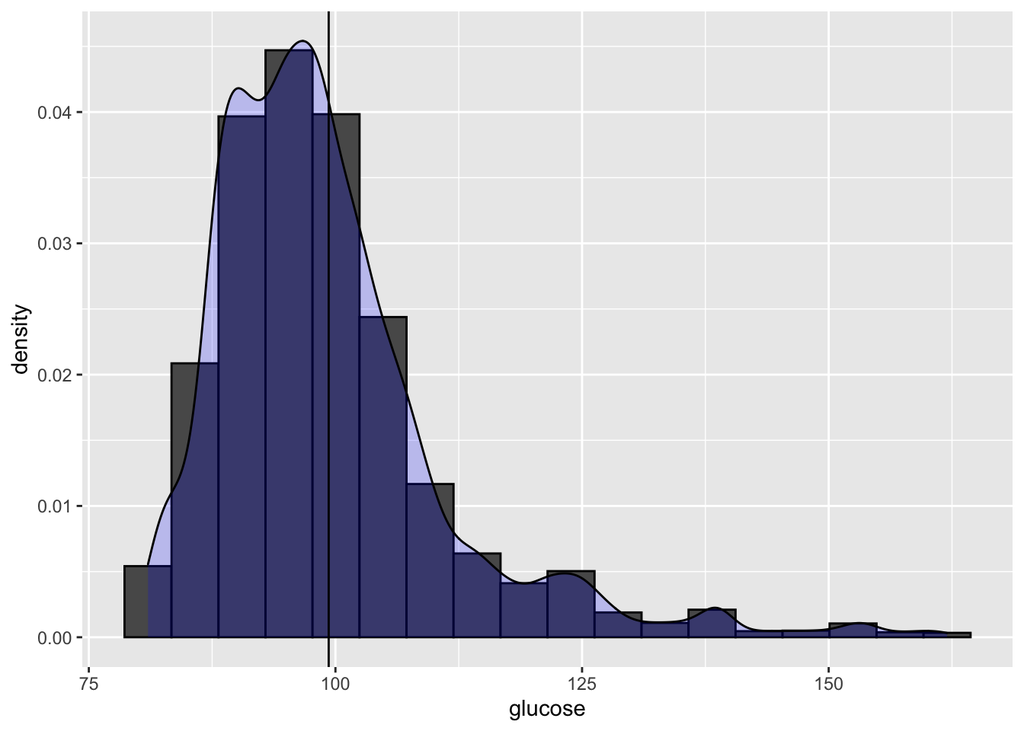

```r
# Generate a histogram with a density estimate
glc.dist.plt <- ggplot(glc, aes(x=glucose)) +
  geom_histogram(aes(y=..density..), colour="black", bins=18) +
    geom_density(alpha=.2, fill="blue") +
    geom_vline(xintercept = mean(glc$glucose)) # Add a vertical line : the mean
print(glc.dist.plt)
```

## Autocovariance function

This is crucial tool for time series analysis. It measures the linear dependence between two points on the same time series, observed at different times. It is mathematically defined as the following second moment product. Notice how once again, the subscript in $\gamma_{x}$ just denotes the time series thus becomming redundant at times.

$$\gamma_{x}(s, t) = cov(x_{s}, x_{t}) = E[(x_{s} - \mu_{s})(x_{t} - \mu_{t})]$$

From here it follows, that for $s = t$, autocovariance reduces to the (assumed finite) variance:

$$\gamma_{x}(t,t) = E[(x_{t} - \mu_{t})^{2}] = var(x_{t})$$

**Note** that $\gamma_{x}(s,t) = 0$ implies that $x_{s}$ and $x_{t}$ are not *linearly* related, but some other form of dependence may exist. However, **if these are bivariate normal**, $\gamma_{x}(s,t) = 0$ ensures their **independence**.

Just as we did with the mean, we define the *sample autocovariance function*:

$$\hat{\gamma}(h) = n^{-1}\sum_{t=1}^{n-h}(x_{t+h} - \bar{x})(x_{t} - \bar{x})$$
Note that this deffinition has be simplified to be a function of the distance $h = | s - t |$ rather than the positions $t$, $s$ themselves. Calulating the *sample autocovariance function* is rather simple in R, as shown by the following example:

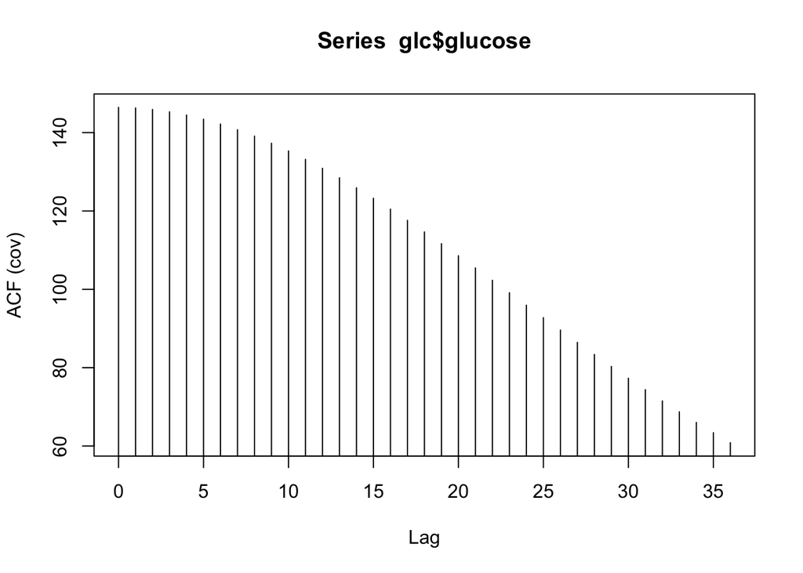

```r
acf(glc$glucose, type = c("covariance"))
```

## Autocorrelation function (ACF)

As we remember from our statistics lectures, correlation measures linear predictability. In this case, we get a notion of how predicatble the time series is a time $t$, i.e. $x_{t}$, using only the value $x_{s}$. Hence we have a rough idea of the ability to forecast the series at time $t$ using the value at time $s$.

$$\rho(s, t) = \frac{\gamma(s, t)}{\sqrt{\gamma(s,s)\gamma(t,t) }}$$
One can show that the **ACF** is bounded using the Cauchy-Schwarz inequality which implies the following:

$$|\gamma(s, t)|^{2} \leq \gamma(s,s) \gamma(t, t) \;\;\;
\longrightarrow \;\;\;
-1 \leq \rho(s, t) \leq 1$$

Analogously to the definition of the *sample autocovariance function*, we can construct the definition for the *sample autocorrelation function* as follows:

$$\hat{\rho}(h) = \frac{\hat{\gamma}(h)}{\hat{\gamma}(0)}$$

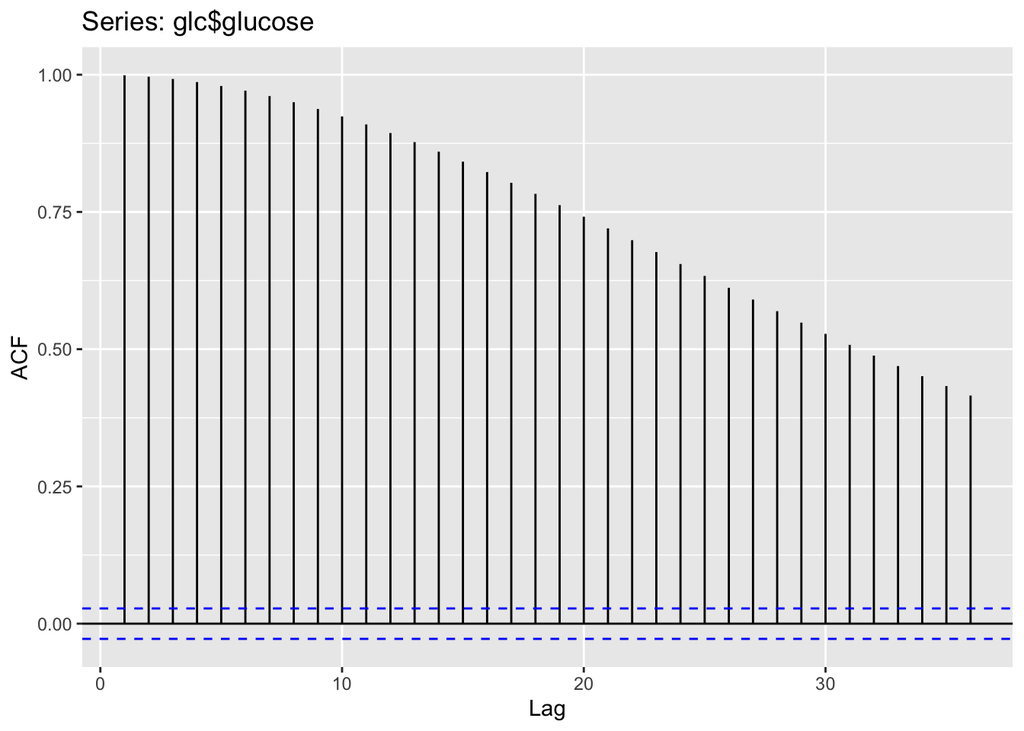

```r
ggAcf(glc$glucose, type = c("correlation"))
```

## Cross-covariance function

As its name implies, this function expresses the covariance between two time series.

$$\gamma_{xy}(s, t) = cov(x_{s}, y_{t}) = E[(x_{s} - \mu_{xs})(y_{t} - \mu_{yt})]$$

Analogously, wa have the *sample cross-covariance function*. Note that we continue to use the simplification $h = | s - t |$, so we’re taking lags instead of the positions.

$$\hat{\gamma}_{xy}(h) = n^{-1}\sum_{t=1}^{n-h}(x_{t+h} - \bar{x})(y_{t} - \bar{y})$$

```r
#diab <- read_csv("../data/multivariate_diabetic_week.csv")
diab <- read_csv(config$data$build$weekly_multiv_diabetic)
#diab$datetime <- sapply(diab$datetime, as_datetime)
mean(diab$glucose)
```

```
## [1] 140.2943
```

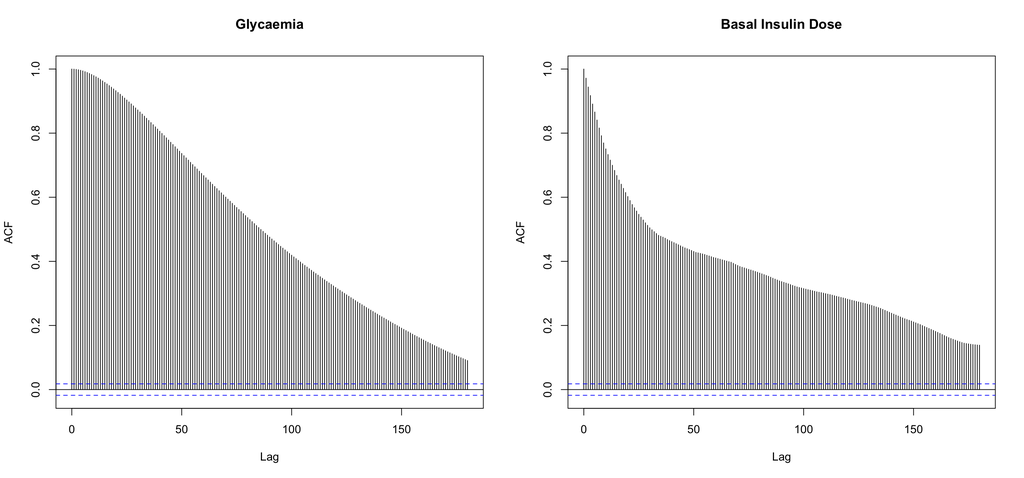

```r
par(mfrow=c(1,2))
acf(diab$glucose, 180, main="Glycaemia")
acf(diab$basal, 180, main="Basal Insulin Dose")
```

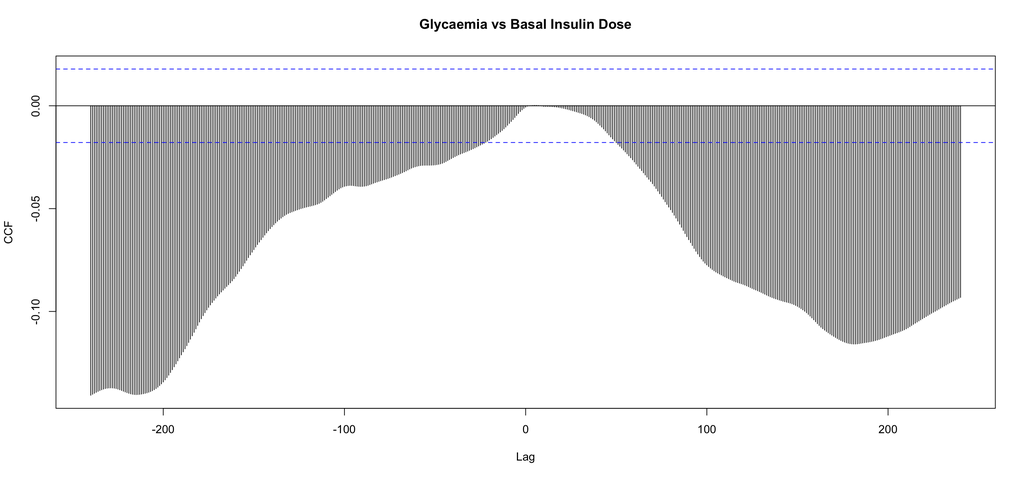

```r
ccf(diab$glucose, diab$basal, 240, main="Glycaemia vs Basal Insulin Dose", ylab="CCF")
```